# Slide Deck slides

## Prosper Loan

### by Titilope Onabajo

### Introduction

### What is the structure of your dataset?

> A data set from Prosper, which is America’s first marketplace lending platform, with over $7 billion in funded loans. This data set contains 113,937 loans with 81 variables on each loan, including loan amount, borrower rate (or interest rate), current loan status, borrower income, borrower employment status, borrower credit history, and the latest payment information.

### What is/are the main feature(s) of interest in your dataset?

> The Borrower's APR will be analyzed with many factors such as the borrower's rating, score, income etc. that could influence change in borrower's APR. Let's also look into what factors are responsible in affecting loan's interest rate.

### What features in the dataset do you think will help support your investigation into your feature(s) of interest?

The features that could help in this investigation are:

- `LoanOriginalAmount`,`IncomeRange`,`CreditGrade`,`LoanStatus`,`BorrowerAPR`, `BorrowerRate`, `StatedMonthlyIncome`, `Term`, `ProsperRating (Alpha)`,`ProsperRating (numeric)`,`EmploymentStatus`,`EstimatedReturn`,`EstimatedLoss`, `DebtToIncomeRatio`

`Borrower's APR` and `Loan's interest interest` are most likely affected by the rest of the features listed above because higher rating reflect the borrower's personality to be more trustworthy. Creditscore could also have similar effect on Borrower's APR as Prosper Rating.Loan's interest rate can also be affected by characteristics like `Monthly Income`,`BorrowerRate`, `Occupation` etc.

### How is Borrower Rate distributed?

> - Borrower's APR rate has a bimodal distribution of, the most frequent APR for borrowing is 30%, followed by 15%,16% and 20% respectively.

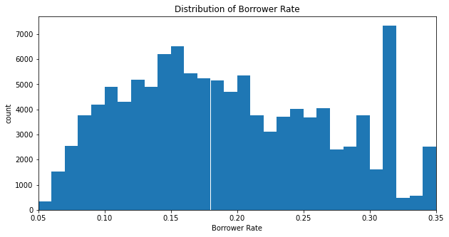

### What is the Income Range of Borrowers?

Comment: 62% of people who borrow from Prosper Loans earn between 0 - 75,000, and 30% earn above 75,000; whilst the 8% remaining fall within 0, not employed and Not displayed

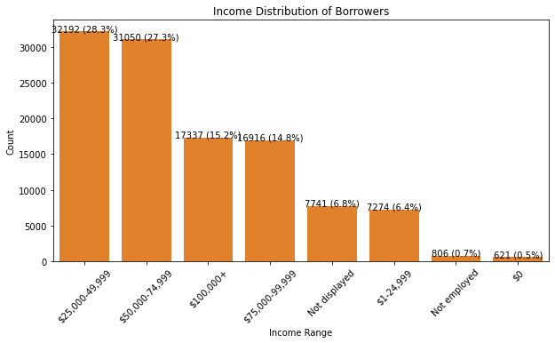

### Distribution of Each Class of Ratings

> The distribution above depicts that the most common rating is C, while on an overall level credit ratings A,B,C and D account for 74%. It can also be inferred that while the ratings increase sporadically between AA and A is because AA is the highest ratings and hence the scutiny and criteria to be fulfilled to attain that credit rating. Also, from Credit rating C, the numbers begin to decline, these needs to be further explored to uncover the underlying reasons behind this distribution.

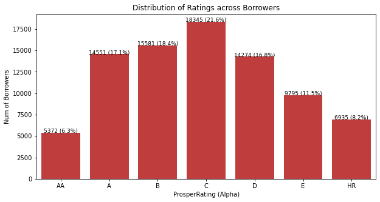

## Loan tenure distribution

> The distribution seen above provides a broad insight into the distribution of the loan term disbursed. 77% of the laon period is usually for 36 months whiile 21.5% is 60 months and 1.4% is within a year. Moreso, the loan term policy of the Loan company might have an impact on the range amount of loan given to borrowers. In order to mitigate risk and repayment default, the company will prefer to disburse loan with repayment period of 1 - 3 years preferably, in order to recover the amount lent and make profit. This hypthesis can be confirmed using the Loan Original Amount data we have in the dataset.

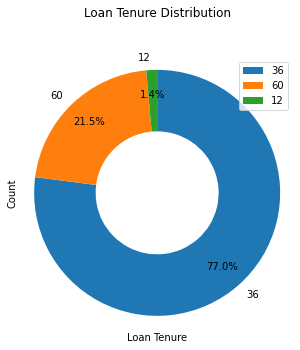

## Bivariate Exploration

## Correlation between Borrower's rate and Income Range Status;

> - Considering the income range and borrower's rate as well, we can identify that borrowers that fall with little or no income category have much higher rate medians than their higher income counterparts. Most likely than not, Prosper Loan determines the rate based on employment status and income range. Looking at the income plot and borrower's rate, there is a slight trend that median rate is lower, when the income range is hogher, except for category 0 dollars. It seems like income range is part of a determining factor for the rate a borrower will get.

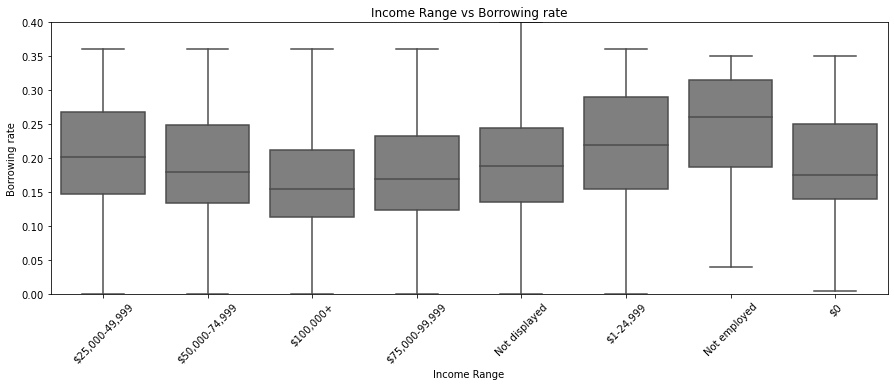

## Loan Term Vs Borrower APR.

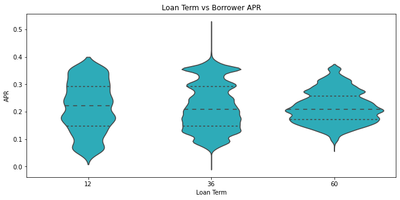

## Multivariate Exploration

## FacetGrid of Prosper Rating (Alpha) Vs. BorrowerAPR

> For high rating A(A), the borrowers has the lowers APR. The patterns also shows the lowerest rating(HR) of borrowers have the highest APR. The lower the rating, the tendencies of paying higher rates on the loan increases

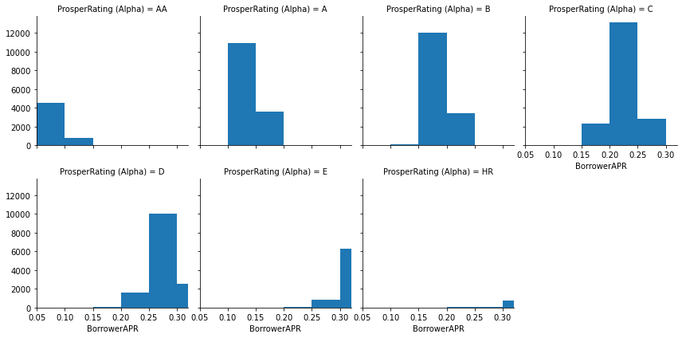

## Income Range Vs. Loan Amount Vs. Loan Term

> It is very interesting in each income range what the loan amount looks like when compared to the income range of the borrowers and time period of the loan. 36 month tenure period stands to be the most dominant period across all income range. However, we begin to notice a break from the norm as the loan amount begins to increase across ranges, especially between 25,000 to above 100,000, at this point and above loan amount of 10,000, loan tenure of 60 months seems to be almost at par with 30 months.

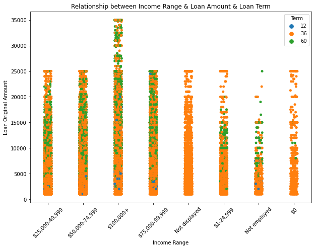